# Final Exam

Please read all of the questions and tables carefully and follow all instructions. Each question has an allotted point value. Be as thorough and specific as possible; extra calculations and incorrect information, even in the presence of correct information, will result in point deductions. Be sure to show all formulas and all necessary work to answer the questions. You may upload your completed exam to the Elms course site.

**Note**

While this is an open-note exam, you are not to receive assistance from anyone else. As usual, the Honor Code applies.

**Total points: 50**

## Conceptual Questions

Please include all work (and computations) necessary to answer the questions.

**Total points: 20 (2 points each)**

### Question 1

Suppose you estimate a bivariate regression model with a total sample size of 50 and obtain a standard error for $\beta_1$ of 2.50. What is the smallest regression coefficient ($\beta_1$) that you could have and still be able to reject the null hypothesis (of no relationship between $X_1$ and $Y$) at the 0.05 level with a one-tailed test?

**Answer**:

```r
#given information
q01_se <- 2.50
q01_n <- 50

#determine degrees of freedom
q01_df <- q01_n - 2

#calculate critical value
q01_tcrit <- qt(0.95, df = q01_df, lower.tail = T)
q01_tcrit
```

```
[1] 1.677224
```

```r
#solve for beta 1
q01_beta01 <- q01_tcrit * q01_se
q01_beta01
```

```
[1] 4.19306
```

The smallest regression coefficient ($\beta_1$) that you could have and still be able to reject the null hypothesis at the 0.05 level with a one-tailed test is 4.1930605.

### Question 2

I regress $Y$ on $X_1$ (i.e., $Y = \beta_0 + \beta_1 X_1$) and find that $\beta_1 = 4.20$, $SE_{\beta_1} = 1.90$, $t = 2.21$, $p = 0.01$, and a 95% confidence interval is [0.48, 7.92]. What is my best estimate of the effect of a two-unit change in $X_1$ on the mean of $Y$ in the population?

**Answer**:

```r
#given information
q02_beta01 <- 4.2

#calculate two-unit change
q2_change <- 2 * q02_beta01
q2_change
```

```
[1] 8.4
```

The best estimate of the effect of a two-unit change in $X_1$ on the mean of $Y$ in the population is 8.4.

### Question 3

I conduct an OLS regression with a sample size of 90 and 5 independent variables. To determine a p-value for each coefficient, I would examine a t-distribution with how many degrees of freedom?

**Answer**:
$$df = n - k$$
Following this equation, we can determine that df = 85.

### Question 4

Suppose I regress $Y$ on $X$ and compute the mean response for $Y$ at some specified value of $X$. When determining the confidence interval around this mean response, which of the following will **NOT** have any effect on the width (or size) of that confidence interval?

1. Total sample size,
2. Mean-squared error,
3. The specified value of $X$,
4. None of the above: all of these (above) will affect the confidence interval,
5. There is not enough information to answer this question.

**Answer**: D

### Question 5

I regress $Y$ on $X$ and find that $\beta_1$ has a two-tailed p-value of 0.04. Which of the following statements is most accurate?

1. The lower and upper bound of a 95% confidence interval around $\beta_1$ will have the same sign,
2. The absolute value for the t-statistic for $\beta_1$ will be greater than 1.96,
3. A 90% confidence interval around $\beta_1$ will not contain zero,
4. All of the above,
5. None of the above and/or there is not enough information.

**Answer**: D

### Question 6

I regress $Y$ on three independent variables – $X_1$, $X_2$, and $X_3$ – and I find the following 95% confidence intervals – $\beta_1$: [0.12, 1.45], $\beta_2$: [-0.01, 0.15], and $\beta_3$: [-0.64, -0.01]. Which of the following statements is most accurate?

1. $\beta_2$ and $\beta_3$ will have negative coefficients, and $\beta_1$ is statistically significant at the 0.05 level (two-tailed),
2. $\beta_1$ will have a positive coefficient, and $\beta_1$ is the only statistically significant coefficient (of the three coefficients) at the 0.05 level (two-tailed),
3. $\beta_1$ will have a positive coefficient, $\beta_2$ and $\beta_3$ will have negative coefficients, and only $\beta_1$ and $\beta_3$ are statistically significant at the 0.05 level (two-tailed),
4. All of the above,
5. None of the above and/or there is not enough information.

**Answer**: E

### Question 7

Suppose I estimate a regression with two independent variables and obtain a $R^2$ of 0.40 where the Residual Sum of Squares is equal to 5,150. What does the Total Sum of Squares equal in this regression model?

**Answer**:
$$R^2 = 1 - \left(\frac{RSS}{TSS}\right)$$
We can solve for the Total sum of squares by reconfiguring this formula.

$$TSS = \left(\frac{RSS}{1 - R^2}\right)$$

```r
q07_rsquared <- 0.40
q07_RSS <- 5150
q07_TSS <- (q07_RSS / (1 - q07_rsquared))
```

TSS = 8583.3333333.

### Question 8

I regress $Y$ on $X_1$ and $X_2$ (i.e., $Y = \beta_0 + \beta_1 X_1 + \beta_2 X_2$). I find that $\beta_1 = -0.87$ with a two-tailed p value of 0.001 and $\beta_2 = 3.52$ with a two-tailed p-value of 0.04. Which of the following statements is most accurate?

1. $X_2$ has a larger substantive effect on $Y$ than $X_1$, but the effect of $X_1$ is more statistically significant,
2. $X_1$ has a larger substantive effect on $Y$ than $X_2$ and $X_1$ is more statistically significant than $X_2$,
3. $X_1$ has a larger substantive effect on $Y$ than $X_2$, but the effect of $X_2$ is more statistically significant,
4. None of the above and/or there is not enough information.

**Answer**: A

### Question 9

I regress $Y$ on $X_1$ (i.e., $Y = \beta_0 + \beta_1 X_1$) and obtain a $R^2$ of 0.45. Then, I regress $Y$ on both $X_1$ and $X_2$ (i.e., $Y = \beta_0 + \beta_1 X_1 + \beta_2 X_2$) and obtain a $R^2$ of 0.53. Which of the following statements must be true?

1. The correlation between $X_1$ and $Y$ is stronger than the correlation between $X_2$ and $Y$,
2. The coefficient on $\beta_1$ is statistically significant in both models,
3. The model with $X_1$ and $X_2$ explains more of the variation in $Y$ than a model with just $X_1$,
4. All of the above: all of these statements are true.

**Answer**: C

### Question 10

Based on the following regression equation, might the negative coefficient on the South variable be the result of southern states having a lower proportion of high school graduates than non-southern states? In no more than one sentence, explain your answer.

$$Turnout = 34 + 0.5(Percent\ High\ School\ Graduates) – 5.9(South)$$

**Answer**: Yes. South is most likely a dummy variable where south is coded as 1, meaning a greater value is being subtracted from the total turnout rate.

## Applied Questions

All datasets referenced below are posted on the ELMs course site.

### Question 1

*Points: 15*

Use the `world` dataset to answer the following questions. The relevant variables and their coding information are as follows: `literacy` indicates a country’s literacy rate; `dem_score14` represents a country’s level of democratization (higher values indicate greater democratization); `spendeduc` reflects the amount of public expenditures on education as a percentage of GDP; `gdp_10_thou` represents GDP per capita (one unit is $10,000 USD); `educ_quality` indicates the average quality rating of a country’s educational system; and `ungr9095` represents the percent average annual population growth.

```r
library(tidyverse)
library(janitor)
library(scales)
library(modelsummary)
library(broom)
library(here)
library(marginaleffects)

#import data
world_df <- read.csv(
  here("world.csv")) |>
  select(literacy, dem_score14, spendeduc, gdp_10_thou, educ_quality, ungr9095)

#preview information
tibble(world_df)
```

```
# A tibble: 169 × 6
   literacy dem_score14 spendeduc gdp_10_thou educ_quality ungr9095
      <dbl>       <dbl>     <dbl>       <dbl>        <dbl>    <dbl>
 1     28.1        2.77      NA        NA            NA         7.3
 2     NA          5.67       2.9       0.154         4.05     -1
 3     69.9        3.83       4.3       0.179         2.67      2.2
 4     67.4        3.35       2.6       0.086         2.24      3.2
 5     97.2        6.84       4.9       0.28          3.20      1.4
 6     99.4        4.13       3         0.077         3.66     -1.9
 7     99          9.01       4.7       2.08          4.78      1.2
 8     98          8.54       5.4       2.54          4.75      0.7
 9     98.8        2.83       1.9       0.075         3.07      1.5
10     86.5        2.87       2.9       1.10          4.12      3.2
# ℹ 159 more rows
```

#### Part A

*Points: 4*

Evaluate the bivariate relationship (using R) between a country’s support for public education and its literacy rate. Report the results in a professionally formatted table. Do countries that spend more money on education appear to have a higher literacy rate?

**Answer**:

```r
#create bivariate model
model_01a <- lm(literacy ~ spendeduc, data = world_df)

#review data
summary(model_01a)
```

```
Call:
lm(formula = literacy ~ spendeduc, data = world_df)

Residuals:
    Min      1Q  Median      3Q     Max
-59.391 -11.024   9.323  15.967  22.258

Coefficients:
            Estimate Std. Error t value Pr(>|t|)
(Intercept)  73.2698     4.2568  17.212   <2e-16 ***
spendeduc     1.7220     0.8731   1.972   0.0505 .
---
Signif. codes:  0 '***' 0.001 '**' 0.01 '*' 0.05 '.' 0.1 ' ' 1

Residual standard error: 20.3 on 140 degrees of freedom
  (27 observations deleted due to missingness)
Multiple R-squared:  0.02704,   Adjusted R-squared:  0.02009
F-statistic:  3.89 on 1 and 140 DF,  p-value: 0.05054
```

```r
#professionally format
modelsummary(model_01a,
             coef_rename = c("literacy" = "Literacy Rate",
                             "spendeduc" = "Public Expenditures on Education (% of GDP)"
             ),
                             statistic = c("t = {statistic}", "SE = {std.error}", "conf.int"))
```

|  | (1) |
| --- | --- |
| (Intercept) | 73.270 |
|  | t = 17.212 |
|  | SE = 4.257 |
|  | [64.854, 81.686] |
| Public Expenditures on Education (% of GDP) | 1.722 |
|  | t = 1.972 |
|  | SE = 0.873 |
|  | [-0.004, 3.448] |
| Num.Obs. | 142 |
| R2 | 0.027 |
| R2 Adj. | 0.020 |
| AIC | 1262.0 |
| BIC | 1270.8 |
| Log.Lik. | -627.987 |
| RMSE | 20.16 |

On average, holding all else constant, every one-point increase in education spending as a percentage of GDP is associated with a 1.7-point increase in literacy rate. However, this is only significant at the .10 level as its p-value (p = 0.051) is just outside of the .05 range.

#### Part B

*Points: 5*

Estimate a second regression model (using R) that includes both a country’s public expenditures on education and its level of democratization as independent variables. When controlling for democratization, does education expenditures exhibit a significant impact on literacy? Report the results in a professionally formatted table. Be sure to discuss the extent to which the results change, and if so, why they changed.

**Answer**:

```r
#create model
model_01b <- lm(literacy ~ spendeduc + dem_score14, data = world_df)

#review data
summary(model_01b)
```

```
Call:
lm(formula = literacy ~ spendeduc + dem_score14, data = world_df)

Residuals:
    Min      1Q  Median      3Q     Max
-52.109  -9.593   3.819  11.272  33.873

Coefficients:
            Estimate Std. Error t value Pr(>|t|)
(Intercept)  53.7017     4.8278  11.124  < 2e-16 ***
spendeduc     0.2582     0.8020   0.322    0.748
dem_score14   4.6504     0.7226   6.435 1.85e-09 ***
---
Signif. codes:  0 '***' 0.001 '**' 0.01 '*' 0.05 '.' 0.1 ' ' 1

Residual standard error: 17.88 on 139 degrees of freedom
  (27 observations deleted due to missingness)
Multiple R-squared:  0.2504,    Adjusted R-squared:  0.2396
F-statistic: 23.21 on 2 and 139 DF,  p-value: 2.002e-09
```

```r
#professionally format
modelsummary(model_01b,
             coef_rename = c("literacy" = "Literacy Rate",
                             "spendeduc" = "Public Expenditures on Education (% of GDP)",
                             "dem_score14" = "Level of Democratization"
             ),
                             statistic = c("t = {statistic}", "SE = {std.error}", "conf.int"))
```

|  | (1) |
| --- | --- |
| (Intercept) | 53.702 |
|  | t = 11.124 |
|  | SE = 4.828 |
|  | [44.156, 63.247] |
| Public Expenditures on Education (% of GDP) | 0.258 |
|  | t = 0.322 |
|  | SE = 0.802 |
|  | [-1.328, 1.844] |
| Level of Democratization | 4.650 |
|  | t = 6.435 |
|  | SE = 0.723 |
|  | [3.222, 6.079] |
| Num.Obs. | 142 |
| R2 | 0.250 |
| R2 Adj. | 0.240 |
| AIC | 1226.9 |
| BIC | 1238.8 |
| Log.Lik. | -609.472 |
| RMSE | 17.69 |

When controlling for democratization, education expenditures no longer exhibits a significant impact on literacy. A lower coefficient and higher p-value indicate that there is no relationship between education expenditures and literacy. Democratization, however, has a strong and significant relationship with literacy. On average and holding all else equal, a one-point increase in democracy score is associated with a 4.65 percentage point increase in literacy rate. This means that democratization is far stronger in explaining an increase in literacy rate in comparison to education expenditures.

#### Part C

*Points: 6*

Now estimate a third model (using R) that includes all of the variables listed above. Report the regression results in a professionally formatted table and interpret each coefficient. When interpreting the impact of democratization using this regression model, present/utilize a visual representation (using R) of the expected change in literacy as a function of democratization.

```r
#create model
model_01c <- lm(literacy ~ spendeduc + dem_score14 + gdp_10_thou + educ_quality + ungr9095, data = world_df)

#review data
summary(model_01c)
```

```
Call:
lm(formula = literacy ~ spendeduc + dem_score14 + gdp_10_thou +
    educ_quality + ungr9095, data = world_df)

Residuals:
    Min      1Q  Median      3Q     Max
-46.171  -5.953   3.517  10.789  28.566

Coefficients:
             Estimate Std. Error t value Pr(>|t|)
(Intercept)   55.9103     8.8978   6.284 5.98e-09 ***
spendeduc      0.1124     0.9232   0.122 0.903342
dem_score14    2.5456     0.9166   2.777 0.006395 **
gdp_10_thou    2.3598     2.0221   1.167 0.245593
educ_quality   3.8118     2.2053   1.728 0.086568 .
ungr9095      -3.3259     0.9460  -3.516 0.000626 ***
---
Signif. codes:  0 '***' 0.001 '**' 0.01 '*' 0.05 '.' 0.1 ' ' 1

Residual standard error: 16.21 on 116 degrees of freedom
  (47 observations deleted due to missingness)
Multiple R-squared:  0.3666,    Adjusted R-squared:  0.3393
F-statistic: 13.43 on 5 and 116 DF,  p-value: 2.492e-10
```

```r
#professionally format
modelsummary(model_01c,
             coef_rename = c("literacy" = "Literacy Rate",
                             "spendeduc" = "Public Expenditures on Education (% of GDP)",
                             "dem_score14" = "Level of Democratization",
                             "gdp_10_thou" = "GDP Per Capita (in tens of thousands)",
                             "educ_quality" = "Quality of Education",
                             "ungr9095" = "Annual Population Growth (in % of total population)"
             ),
                             statistic = c("t = {statistic}", "SE = {std.error}", "conf.int"))
```

|  | (1) |
| --- | --- |
| (Intercept) | 55.910 |
|  | t = 6.284 |
|  | SE = 8.898 |
|  | [38.287, 73.534] |
| Public Expenditures on Education (% of GDP) | 0.112 |
|  | t = 0.122 |
|  | SE = 0.923 |
|  | [-1.716, 1.941] |
| Level of Democratization | 2.546 |
|  | t = 2.777 |
|  | SE = 0.917 |
|  | [0.730, 4.361] |
| GDP Per Capita (in tens of thousands) | 2.360 |
|  | t = 1.167 |
|  | SE = 2.022 |
|  | [-1.645, 6.365] |
| Quality of Education | 3.812 |
|  | t = 1.728 |
|  | SE = 2.205 |
|  | [-0.556, 8.180] |
| Annual Population Growth (in % of total population) | -3.326 |
|  | t = -3.516 |
|  | SE = 0.946 |
|  | [-5.200, -1.452] |
| Num.Obs. | 122 |
| R2 | 0.367 |
| R2 Adj. | 0.339 |
| AIC | 1033.8 |
| BIC | 1053.4 |
| Log.Lik. | -509.901 |
| RMSE | 15.81 |

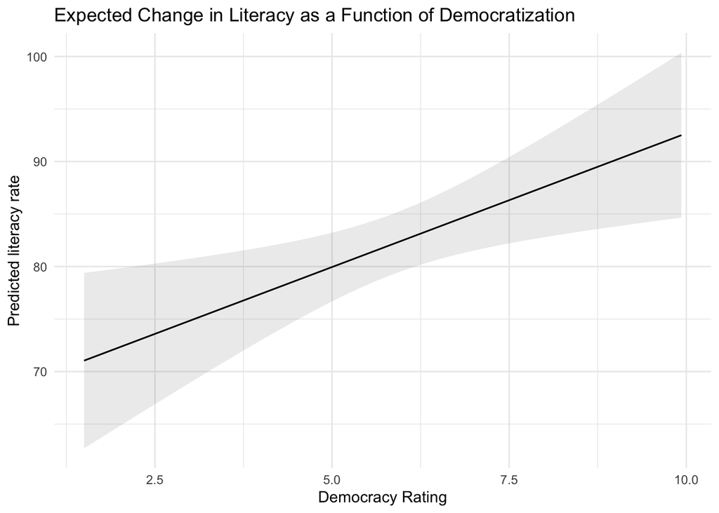

```r
#plot data
plot_predictions(model_01c, condition = "dem_score14") +
  labs(title = "Expected Change in Literacy as a Function of Democratization",
       x = "Democracy Rating",
       y = "Predicted literacy rate") +
  theme_minimal()
```

On average, a one point increase in education expenditure is associated with a 0.11 increase in literacy rate, holding all else equal. However, consistent with previous analysis, education expenditure does not have a significant relationship with literacy rate when controlling for democratization, GDP per capita, education quality, and population growth.

Democratization maintains its significant relationship to literacy rate at the .01 level (p < 0.01). . It does have a lower coefficient, suggesting that it does not hold as much explanatory power. On average, and holding all else equal, a one-point increase in democracy score is associated with a 2.55-point increase in literacy rate. Simply put, democracies tend to have higher literacy rates.

On average, holding all else equal, a one point increaes in GDP per capita and literacy rate is associated with a 2.36 point increase in literacy rate. However, this is not a statistically significant relationship.

Education quality rating and literacy rate have a significant relationship only at the .10 level (p = 0.087). On average, a one-point increase in education quality rating is associated with a 3.81 point increase in literacy rate, holding all else equal. This suggests a pontential relationship between countries with higher education quality ratings and literacy rate.

The relationship between population growth and literacy rate is extremely significant (p < 0.001). Unlike previous variables, this relationship is negative. On average, a one-point increase in population growth rate is associated with a 3.33 point decrease in literacy rate. This means that growing countries tend to have lower literacy rates.

### Question 2

*Points: 15*

Using the `states` dataset, use R to regress the variable `obama08` (the percentage of a state’s vote that President Obama received in the 2008 U.S. presidential election) on the following independent variables: `cig_tax` represents the amount of a state’s cigarette tax (in dollars); `college` is the percentage of a state’s population that graduated college (0 to 100); `union07` is the percentage of a state’s workers that are union members (0 to 100); and `south` is a dichotomous variable coded as `1` if the state is located in the South (`0` otherwise). Report the results in a professionally formatted table. Answer the following questions.

```r
#import data
states_df <- read.csv(
  here("states.csv")) |>
  select(obama08, cig_tax, college, union07,south)

#create multivariate model
model_02 <- lm(obama08 ~ cig_tax + college + union07 + south, data = states_df)

#review data
summary(model_02)
```

```
Call:
lm(formula = obama08 ~ cig_tax + college + union07 + south, data = states_df)

Residuals:
     Min       1Q   Median       3Q      Max
-22.9236  -2.8210   0.7792   3.9089  11.7132

Coefficients:
            Estimate Std. Error t value Pr(>|t|)
(Intercept)  16.1280     6.5909   2.447 0.018374 *
cig_tax       0.5230     2.2306   0.234 0.815676
college       0.9646     0.2461   3.920 0.000299 ***
union07       0.7514     0.2439   3.081 0.003511 **
south         1.3928     2.5885   0.538 0.593179
---
Signif. codes:  0 '***' 0.001 '**' 0.01 '*' 0.05 '.' 0.1 ' ' 1

Residual standard error: 6.869 on 45 degrees of freedom
Multiple R-squared:  0.5201,    Adjusted R-squared:  0.4775
F-statistic: 12.19 on 4 and 45 DF,  p-value: 8.504e-07
```

```r
#format table
modelsummary(model_02,
             coef_rename = c(
             "obama08" = "Percent of State's Vote for Obama in 2008",
             "college" = "Percentage of State Population that Graduated College",
             "cig_tax" = "Amount of a State's Cigarette Tax (in USD)",
             "union07" = "Percentage of State's Workers that are Union Members",
             "south" = "Southern State"),
             statistic = c("t = {statistic}", "SE = {std.error}", "conf.int"))
```

|  | (1) |
| --- | --- |
| (Intercept) | 16.128 |
|  | t = 2.447 |
|  | SE = 6.591 |
|  | [2.853, 29.403] |
| Amount of a State's Cigarette Tax (in USD) | 0.523 |
|  | t = 0.234 |
|  | SE = 2.231 |
|  | [-3.970, 5.016] |
| Percentage of State Population that Graduated College | 0.965 |
|  | t = 3.920 |
|  | SE = 0.246 |
|  | [0.469, 1.460] |
| Percentage of State's Workers that are Union Members | 0.751 |
|  | t = 3.081 |
|  | SE = 0.244 |
|  | [0.260, 1.243] |
| Southern State | 1.393 |
|  | t = 0.538 |
|  | SE = 2.588 |
|  | [-3.821, 6.606] |
| Num.Obs. | 50 |
| R2 | 0.520 |
| R2 Adj. | 0.477 |
| AIC | 341.3 |
| BIC | 352.8 |
| Log.Lik. | -164.666 |
| RMSE | 6.52 |

#### Part A

*Points: 6*

Interpret the substantive results from this regression model. Be sure to discuss the direction, magnitude, and statistical significance of each slope coefficient. Does the `union07` variable exhibit a substantively significant impact on voting behavior in the 2008 election?

**Answer**: There is a statistically insignificant relationship between amount of state cigarette tax and a state’s percentage of votes fro Obama in 2008. Nonetheless, the regression returns that holding all else equal, the amount of a state’s cigarette tax is associated with a 0.52 increase in percentage of state’s votes going to Obama in 2008, on average.

A one point increase in percentage of state population graduating college is associated with a 0.97 point increase in percentage of state’s vote going to Obama in 2008, on average and holding all else equal. This positive relationship is extremely significant (p < 0.001).

A one point increase in percentage of state’s workers that are union members is associated with a 0.75 point increase in percentage of state’s vote going to Obama in 2008, on average and holding all else equal. This positive relationship exhbits a extremely significant substantive impact (p < 0.01).

Southern states are associated with a 1.39 point increase in percentage of state’s vote going to Obama 2008, on average holding all else equal. This positive relationship is not statistically signicant (p = 0.59).

#### Part B

*Points: 2*

Interpret the intercept coefficient. What does this represent and is it meaningful to interpret this coefficient on its own? Why or why not?

**Answer**: The interept represents the value of percentage of state’s votes for Obama in 2008 when all independent variables’ values are at zero. Interpreted substantively, states with no cigarette tax, no college graduates, and no unionized workers are expected to have a mean 16.13% turnout for Obama in 2008. This is not substantively meaningful since it is unrealistic for a state to exhibit all of these qualities.

#### Part C

*Points: 2*

What is the expected mean percentage of Obama’s vote total in a Southern state with a cigarette tax of $2.00, a state population where 30% of people are college graduates, and where 15% of workers in a state are union members?

**Answer**: From the regression we can derive this equation:

$$\text{Obama08} = \text{Intercept} + (\beta_{\text{cig\_tax}} \times \text{cig\_tax}) + (\beta_{\text{college}} \times \text{college}) + (\beta_{\text{union07}} \times \text{union07}) + (\beta_{\text{south}} \times \text{south})$$
We can substitute these variables into the equation.

```r
beta_cig_tax <- 0.5230
beta_college <- 0.9646
beta_union07 <- 0.7514
beta_south <- 1.3928
model02_intercept <- 16.1280

q02c_obama08 <- model02_intercept + (beta_cig_tax * 2) + (beta_college * .30) + (beta_union07 * .15) + (beta_south * 1)
q02c_obama08
```

```
[1] 18.96889
```

The expected mean percentage of Obama’s vote total in this theoretical Southern state is 18.96889.

#### Part D

*Points: 3*

What is a 90% confidence interval around the coefficient for the `south` variable.

**Answer**: We can calculate this confidence interval using the following equation:
$$CI_{\beta_j} = \beta_j \pm t \cdot SE_{\beta_j}$$

```r
#given variable
SE_south <- 2.588
df_02 <- model_02$df.residual

#find t-value
t_south <- qt(0.95, df = df_02)

#Find confidence interval
upper_south <- beta_south + (t_south * SE_south)
lower_south <- beta_south - (t_south * SE_south)
```

A 90% confidence interval around the coefficient for the `south` variable is [-2.9535581,5.7391581].

#### Part E

*Points: 3*

What is the null hypothesis that the F-test in this regression output is testing?

**Answer**: The null hypothesis is:
$$H_0: \beta_{\text{cig\_tax}} = \beta_{\text{college}} = \beta_{\text{union07}} = \beta_{\text{south}} = 0$$
In other words, the independent variables `cig_tax`, `college`, `union07`, and `south` do not explain any variation in state turnout for Obama in 2008.